[figure not shown]

# Informe valoració treballs en grup

# 1 Visualización de los datos de entrada

```r
# Visualizamos la información que obtenemos de los datos
## Descriptiva univariante de todas las variables
psych::describe(dades)
```

```
##           vars  n        mean        sd   median     trimmed      mad      min
## DNI          1 63 20334932.95 735860.14 20552980 20474319.29 98183.70 16508236
## NOMBRES      2 63       32.00     18.33       32       32.00    23.72        1
## GRUPO        3 63        4.49      2.34        4        4.49     2.97        1
## ALUMNO_1     4 63        1.57      1.72        1        1.06     0.00        1
## ALUMNO_2     5 63        0.98      2.81        0        0.16     0.00        0
## ALUMNO_3     6 63        1.11      2.96        0        0.28     0.00        0
## ALUMNO_4     7 63        0.99      2.73        0        0.19     0.00        0
## ALUMNO_5     8 63        1.08      3.07        0        0.18     0.00        0
## ALUMNO_6     9 63        0.55      1.89        0        0.07     0.00        0
## ALUMNO_7    10 63        1.56      1.65        1        1.06     0.00        1
## ALUMNO_8    11 63        1.56      1.65        1        1.06     0.00        1
## ALUMNO_9    12 63        1.22      3.23        0        0.36     0.00        0
## ALUMNO_10   13  0         NaN        NA       NA         NaN       NA      Inf
## ALUMNO_11   14 63        1.08      3.07        0        0.18     0.00        0
## ALUMNO_12   15 63        1.23      3.24        0        0.37     0.00        0
## ALUMNO_13   16 63        1.23      3.24        0        0.37     0.00        0
## ALUMNO_14   17 63        1.60      1.63        1        1.12     0.00        1
## ALUMNO_15   18 63        1.07      3.04        0        0.18     0.00        0
## ALUMNO_16   19 63        1.57      1.72        1        1.06     0.00        1
## ALUMNO_17   20 63        1.06      3.02        0        0.18     0.00        0
## ALUMNO_18   21 63        1.67      1.84        1        1.12     0.00        1
## ALUMNO_19   22 63        1.57      1.72        1        1.06     0.00        1
## ALUMNO_20   23 63        0.96      2.83        0        0.06     0.00        0
## ALUMNO_21   24 63        1.67      1.84        1        1.12     0.00        1
## ALUMNO_22   25 63        1.22      3.23        0        0.36     0.00        0
## ALUMNO_23   26  0         NaN        NA       NA         NaN       NA      Inf
## ALUMNO_24   27 63        1.23      3.24        0        0.37     0.00        0
## ALUMNO_25   28  0         NaN        NA       NA         NaN       NA      Inf
## ALUMNO_26   29 63        1.57      1.72        1        1.06     0.00        1
## ALUMNO_27   30  0         NaN        NA       NA         NaN       NA      Inf
## ALUMNO_28   31 63        1.06      3.03        0        0.18     0.00        0
## ALUMNO_29   32 63        0.96      2.55        0        0.28     0.00        0
## ALUMNO_30   33 63        1.23      3.24        0        0.37     0.00        0
## ALUMNO_31   34 63        1.57      1.72        1        1.06     0.00        1
## ALUMNO_32   35 63        1.67      1.84        1        1.12     0.00        1
## ALUMNO_33   36 63        1.07      3.04        0        0.18     0.00        0
## ALUMNO_34   37 63        1.56      1.65        1        1.06     0.00        1
## ALUMNO_35   38 63        1.08      3.07        0        0.18     0.00        0
## ALUMNO_36   39 63        0.84      2.55        0        0.04     0.00        0
```

[output cut: 79 more lines]

```
## ALUMNO_49       -Inf      -Inf    NA       NA       NA
## ALUMNO_50       10.0      10.0  2.42     3.92     0.39
## ALUMNO_51       10.0      10.0  2.19     2.85     0.41
## ALUMNO_52        8.7       8.7  2.20     2.89     0.35
## ALUMNO_53       10.0      10.0  2.19     2.85     0.41
## ALUMNO_54       10.0      10.0  2.20     2.91     0.40
## ALUMNO_55       10.0      10.0  2.19     2.85     0.41
## ALUMNO_56       10.0      10.0  2.19     2.85     0.41
## ALUMNO_57        9.9       9.9  2.42     3.92     0.38
## ALUMNO_58       10.0      10.0  2.21     2.94     0.40
## ALUMNO_59        8.6       8.6  2.20     2.93     0.34
## ALUMNO_60       10.0      10.0  2.42     3.92     0.39
## ALUMNO_61       10.0      10.0  2.42     3.92     0.39
## ALUMNO_62       10.0      10.0  2.19     2.85     0.41
## ALUMNO_63       10.0      10.0  2.43     4.03     0.36
```

# 2 Perdida de estudiantes

## 2.1 No Presentados

```
## [1] "OJO: Hay columnas de notas que contienen NP. Se deberia de revisar"
```

```
## OK: Tenemos 6 que han abandonado la asignatura y sus compañeros así lo notifican.
```

```
## OJO: Tenemos 6 alumnos que no han realizado la evauación. Tocará investigar.
```

## 2.2 Bajas

## 2.3 Supervivientes

```
## Aqui tenemos las distribuciones de los alumnos por grupos:
```

| grups | n | Baixes | nGrupReal |
| --- | --- | --- | --- |
| G01Aerolinies | 8 | 1 | 7 |
| G02Hotels | 8 | 0 | 8 |
| G03Terrorisme | 8 | 2 | 6 |
| G04Billonarios | 8 | 0 | 8 |
| G05Marketing | 8 | 0 | 8 |
| G06SalutMental | 7 | 0 | 7 |
| G07Salaries | 7 | 0 | 7 |
| G08Pisa | 9 | 3 | 6 |

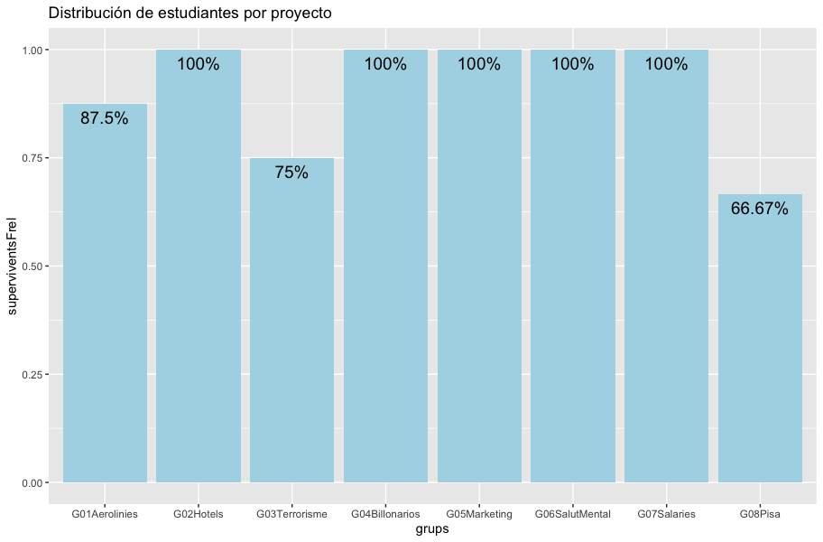

```
## Alerta! abans d'eliminar els que han abandonat, hem de saber de quin grup son
```

# 3 Generación de KPIs

## 3.1 Auto-evaluación

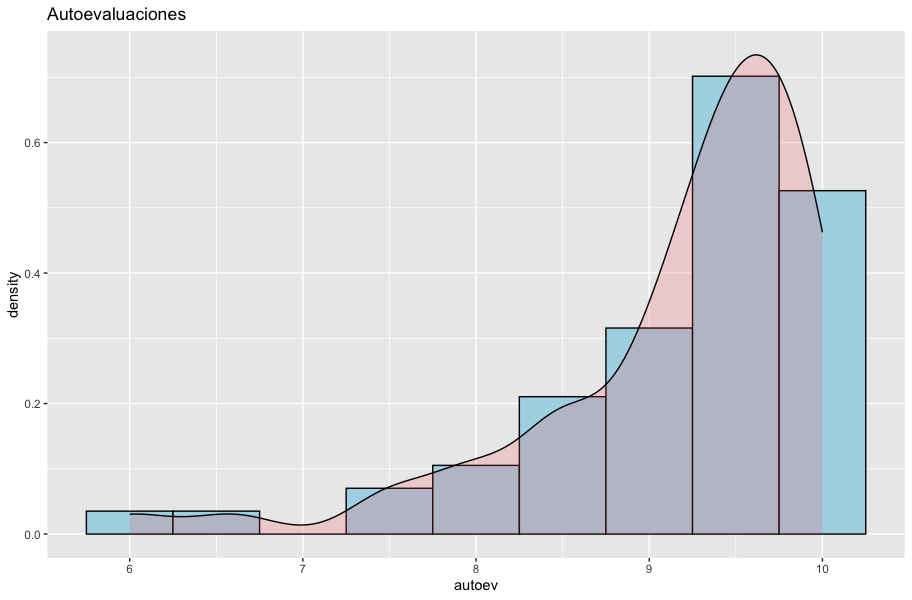

## 3.2 mitCEestudiant

```
## Number of cases in table: 57
## Number of factors: 2
## Test for independence of all factors:
##  Chisq = 349, df = 336, p-value = 0.3018
##  Chi-squared approximation may be incorrect
```

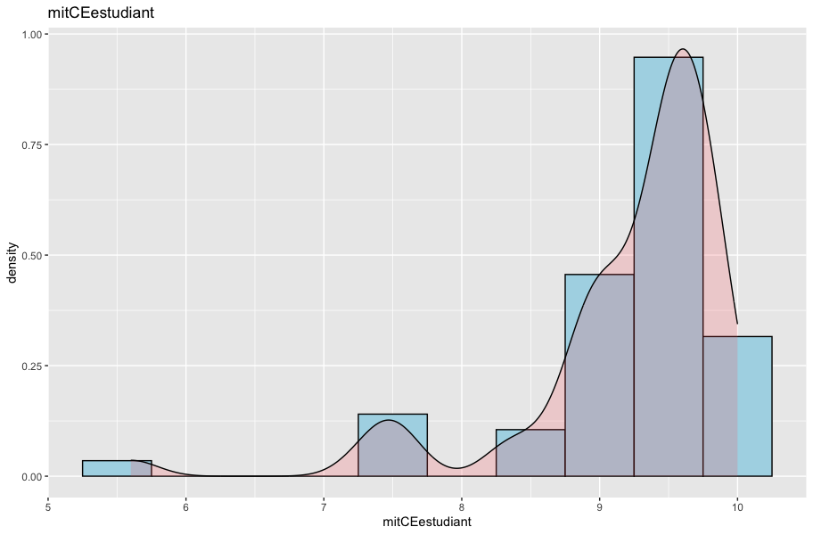

| Min. | 1st Qu. | Median | Mean | 3rd Qu. | Max. | NA |
| --- | --- | --- | --- | --- | --- | --- |
| 9.300 | 9.60000 | 9.6500 | 9.650000 | 9.75850 | 9.883 | 1 |
| 9.029 | 9.37825 | 9.5715 | 9.546500 | 9.80025 | 10.000 | NA |
| 5.600 | 8.45500 | 9.1350 | 8.603333 | 9.63500 | 9.720 | 2 |
| 8.671 | 8.88600 | 8.9885 | 9.019375 | 9.10150 | 9.471 | NA |
| 7.471 | 8.93950 | 9.0855 | 9.005375 | 9.49300 | 9.529 | NA |
| 9.450 | 9.58350 | 9.6500 | 9.642857 | 9.67500 | 9.883 | NA |
| 9.317 | 9.40850 | 9.4500 | 9.514429 | 9.62500 | 9.767 | NA |
| 7.300 | 7.51250 | 7.9800 | 8.395000 | 9.43000 | 9.840 | 3 |

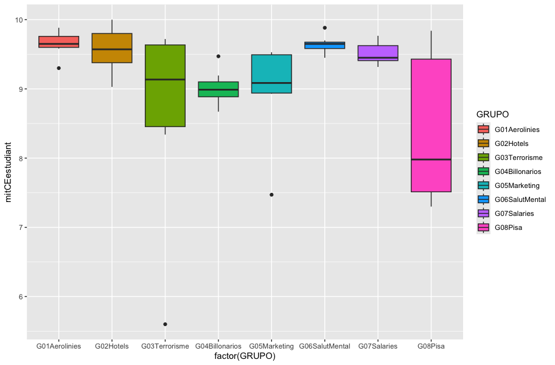

## 3.3 MitjanaCEPractica

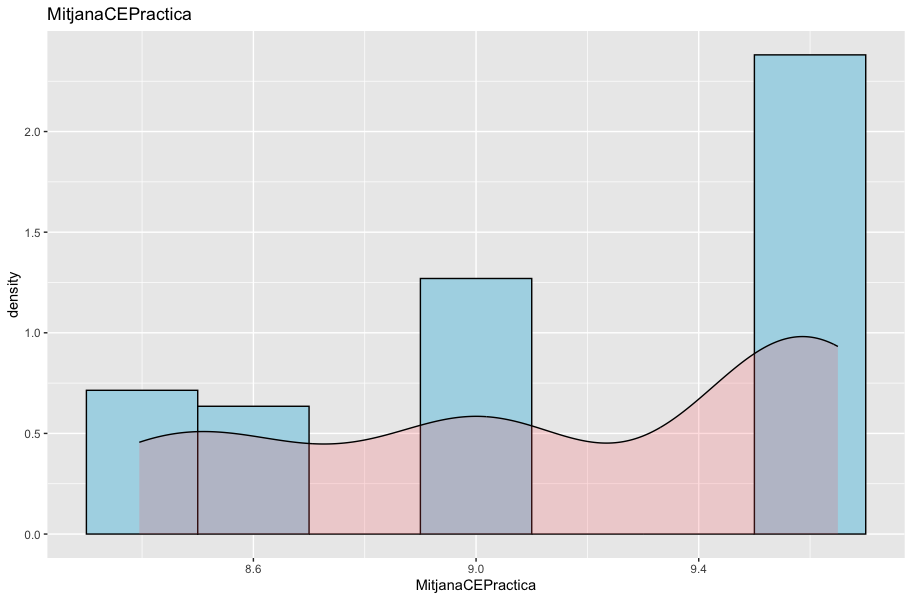

## 3.4 BonificacióCE

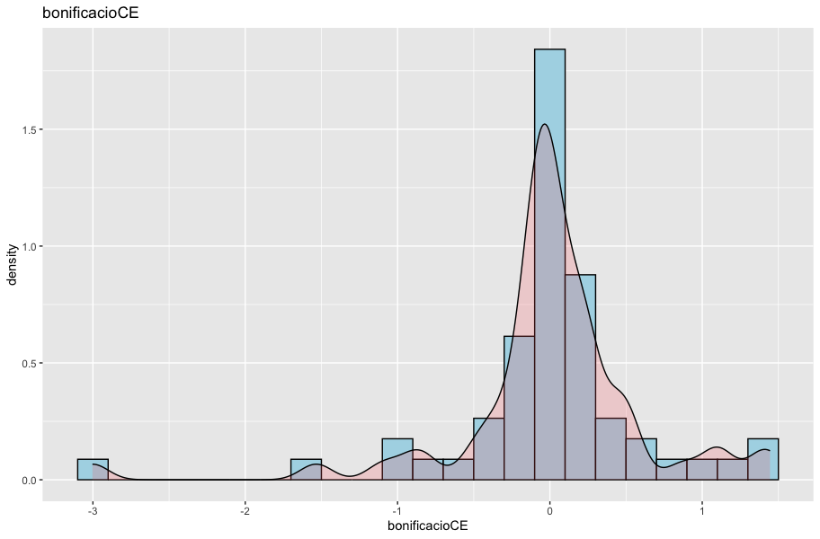

## 3.5 Afectación Individual

La **afectación individual** se suma/resta directamente a la calificación grupal final de la práctica atorgada por los profesores

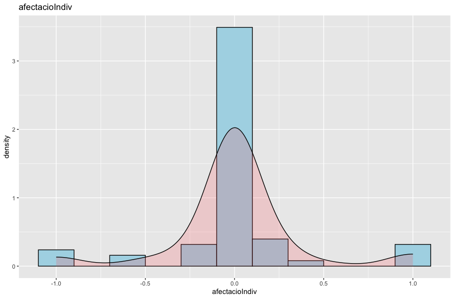

## 3.6 Autoexigencia

La **autoexigencia** es el porcentaje (%) de compañeros que han evaluado con la mejor nota que tu mismo.

Sea:

- $E$ el número total de compañeros que evalúan (excluyéndote a ti mismo).
- $B$ el número de compañeros que han evaluado con la mejor nota que tú mismo.

Entonces, la **autoexigencia** se puede expresar como el porcentaje de compañeros que han evaluado con la mejor nota que tú mismo, de la siguiente manera:

$$\text{Autoexigencia} = \left( \frac{B}{E} \right) \times 100 \, \%$$

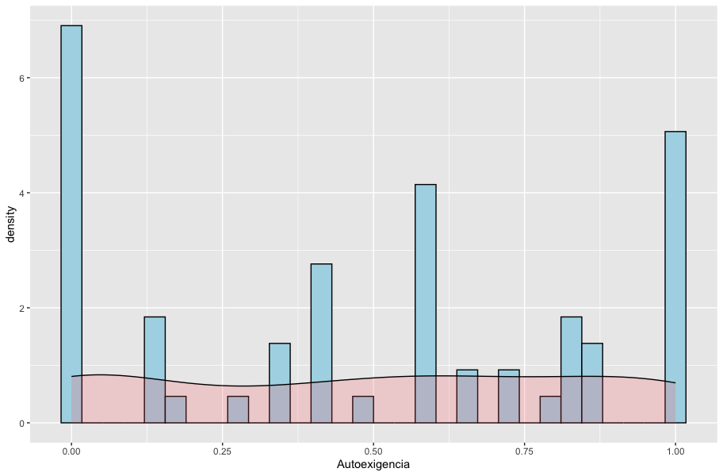

## 3.7 Sobrevaloración

La **autosobrevaloración** es el porcentaje (%) de compañeros que te han evaluado con la peor nota que tu mismo.

Sea:

- $E$ el número total de compañeros que te han evaluado.
- $P$ el número de compañeros que te han evaluado con una nota peor que la que tú te has asignado.

Entonces, la **autosobrevaloración** se puede expresar como el porcentaje de compañeros que te han evaluado con una nota peor que la tuya propia, de la siguiente manera:

$$\text{Autosobrevaloración} = \left( \frac{P}{E} \right) \times 100 \, \%$$

donde el resultado es el porcentaje de compañeros que te han calificado más bajo de lo que tú te calificaste a ti mismo.

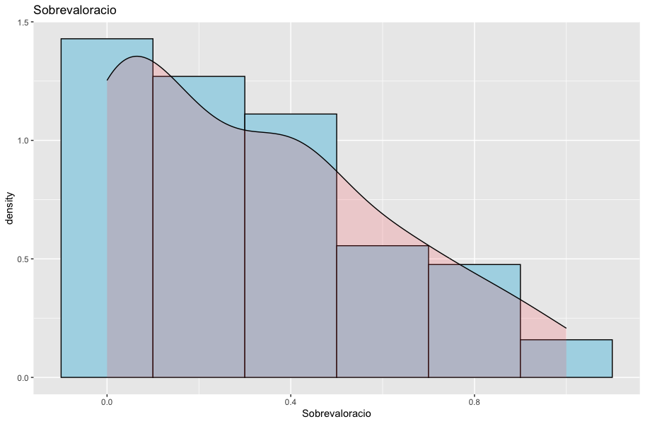

## 3.8 Liderazgo

El **liderazgo** es el porcentaje (%) de compañeros que te han puesto la mejor nota del grupo.

Sea:

- $E$ el número total de compañeros que te han evaluado.
- $M$ el número de compañeros que te han asignado la mejor nota del grupo.

Entonces, el **liderazgo** se puede expresar como el porcentaje de compañeros que te han dado la mejor nota del grupo, de la siguiente manera:

$$\text{Liderazgo} = \left( \frac{M}{E} \right) \times 100 \, \%$$

donde el resultado es el porcentaje de compañeros que consideran que tienes la mejor calificación del grupo.

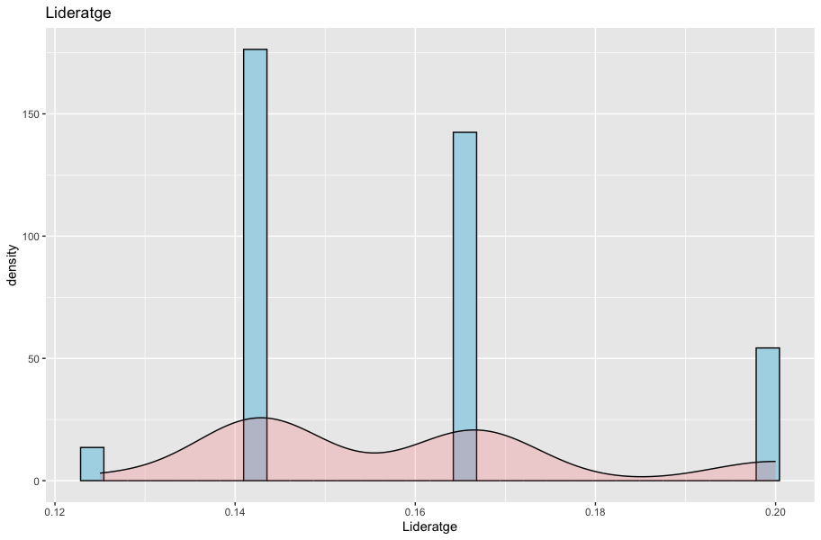

## 3.9 Alienación

La **alienación** es el porcentaje (%) de compañeros que te han puesto la peor nota del equipo.

Sea:

- $E$ el número total de compañeros que te han evaluado.
- $L$ el número de compañeros que te han asignado la peor nota del equipo.

Entonces, la **alienación** se puede expresar como el porcentaje de compañeros que te han dado la peor nota del equipo, de la siguiente manera:

$$\text{Alienación} = \left( \frac{L}{E} \right) \times 100 \, \%$$

donde el resultado es el porcentaje de compañeros que consideran que tienes la calificación más baja dentro del equipo.

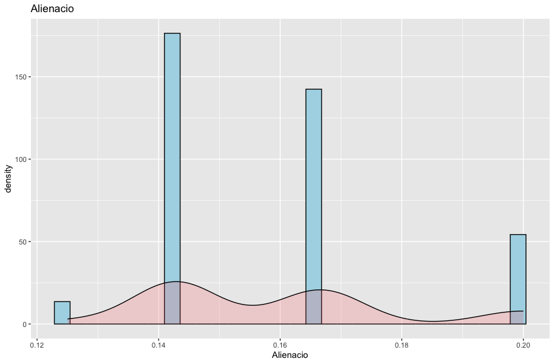

## 3.10 Disfunción

La **disfunción** quasi-desvicacio tipica normalizada de les qualificacions rebudes pels companys (indica si la percepcio que els altres tenen es la mateixa per tothom o es molt heterogenia)

Sea:

- $q_1, q_2, \dots, q_n$ las **calificaciones recibidas** de cada uno de los $n$ compañeros.
- $\bar{q}$ la **media** de las calificaciones recibidas.
- $\sigma_q$ la **desviación estándar** de las calificaciones recibidas, calculada como:

  $$\sigma_q = \sqrt{\frac{1}{n} \sum_{i=1}^{n} (q_i - \bar{q})^2}$$

La **disfunción** se puede expresar como la **desviación típica normalizada** de las calificaciones recibidas:

$$\text{Disfunción} = \frac{\sigma_q}{\bar{q}}$$

donde un valor alto de disfunción indica una percepción muy heterogénea entre los compañeros (es decir, las calificaciones varían mucho), y un valor bajo indica una percepción más uniforme.

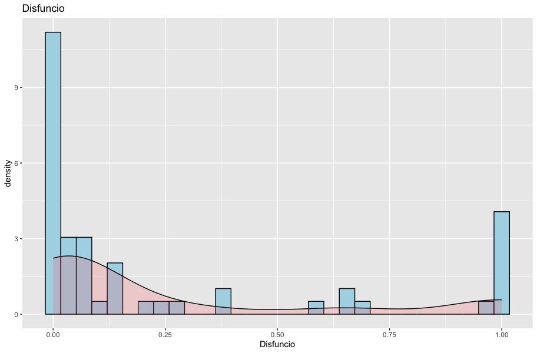

## 3.11 Resum general

|  | vars | n | mean | sd | median | trimmed | mad | min | max | range | skew | kurtosis | se |
| --- | --- | --- | --- | --- | --- | --- | --- | --- | --- | --- | --- | --- | --- |
| autoev | 1 | 57 | 9.163 | 0.842 | 9.400 | 9.296 | 0.593 | 6.000 | 10.000 | 4.000 | -1.701 | 2.974 | 0.111 |
| mitCEestudiant | 1 | 57 | 9.197 | 0.790 | 9.471 | 9.347 | 0.439 | 5.600 | 10.000 | 4.400 | -2.319 | 6.380 | 0.105 |
| MitjanaCEPractica | 1 | 63 | 9.147 | 0.470 | 9.019 | 9.176 | 0.781 | 8.395 | 9.650 | 1.255 | -0.368 | -1.427 | 0.059 |
| bonificacioCE | 1 | 57 | 0.000 | 0.653 | -0.005 | 0.031 | 0.279 | -3.003 | 1.445 | 4.448 | -1.508 | 6.774 | 0.087 |
| afectacioIndiv | 1 | 63 | 0.012 | 0.366 | 0.000 | 0.005 | 0.000 | -1.000 | 1.000 | 2.000 | 0.192 | 3.360 | 0.046 |
| Autoexigencia | 1 | 63 | 0.489 | 0.369 | 0.571 | 0.486 | 0.424 | 0.000 | 1.000 | 1.000 | -0.036 | -1.446 | 0.046 |
| Sobrevaloracio | 1 | 63 | 0.319 | 0.292 | 0.286 | 0.288 | 0.424 | 0.000 | 1.000 | 1.000 | 0.594 | -0.715 | 0.037 |
| Lideratge | 1 | 57 | 0.159 | 0.021 | 0.167 | 0.157 | 0.035 | 0.125 | 0.200 | 0.075 | 0.745 | -0.363 | 0.003 |
| Alienacio | 1 | 57 | 0.159 | 0.021 | 0.167 | 0.157 | 0.035 | 0.125 | 0.200 | 0.075 | 0.745 | -0.363 | 0.003 |
| Disfuncio | 1 | 57 | 0.253 | 0.368 | 0.052 | 0.201 | 0.077 | 0.000 | 1.000 | 1.000 | 1.239 | -0.151 | 0.049 |

# 4 Anàlisi dels grups

## 4.1 G01Aerolinies

|  | alumne | Autoexigencia | Sobrevaloracio | Lideratge | Alienacio | Disfuncio |
| --- | --- | --- | --- | --- | --- | --- |
| 1 | ALUMNO_1 | 0.167 | 0.500 | 0.167 | 0.167 | 1.000 |
| 16 | ALUMNO_16 | 0.000 | 1.000 | 0.167 | 0.167 | 0.080 |
| 19 | ALUMNO_19 | 0.000 | 0.667 | 0.167 | 0.167 | 0.000 |
| 26 | ALUMNO_26 | 0.500 | 0.333 | 0.167 | 0.167 | 0.080 |
| 27 | ALUMNO_27 | NA | NA | NA | NA | NA |
| 31 | ALUMNO_31 | 0.833 | 0.167 | 0.167 | 0.167 | 0.080 |
| 37 | ALUMNO_37 | 1.000 | 0.000 | 0.167 | 0.167 | 0.000 |
| 48 | ALUMNO_48 | 0.333 | 0.667 | 0.167 | 0.167 | 0.052 |

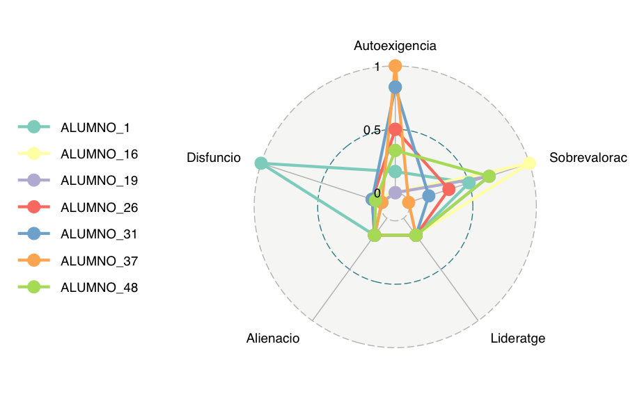

## 4.2 G02Hotels

|  | alumne | Autoexigencia | Sobrevaloracio | Lideratge | Alienacio | Disfuncio |
| --- | --- | --- | --- | --- | --- | --- |
| 3 | ALUMNO_3 | 1.000 | 0.000 | 0.143 | 0.143 | 1.000 |
| 12 | ALUMNO_12 | 0.000 | 0.000 | 0.143 | 0.143 | 0.000 |
| 24 | ALUMNO_24 | 0.000 | 0.143 | 0.143 | 0.143 | 0.024 |
| 38 | ALUMNO_38 | 0.286 | 0.571 | 0.143 | 0.143 | 0.046 |
| 42 | ALUMNO_42 | 1.000 | 0.000 | 0.143 | 0.143 | 0.046 |
| 46 | ALUMNO_46 | 0.143 | 0.714 | 0.143 | 0.143 | 0.046 |
| 56 | ALUMNO_56 | 0.143 | 0.286 | 0.143 | 0.143 | 0.039 |
| 58 | ALUMNO_58 | 0.857 | 0.143 | 0.143 | 0.143 | 0.000 |

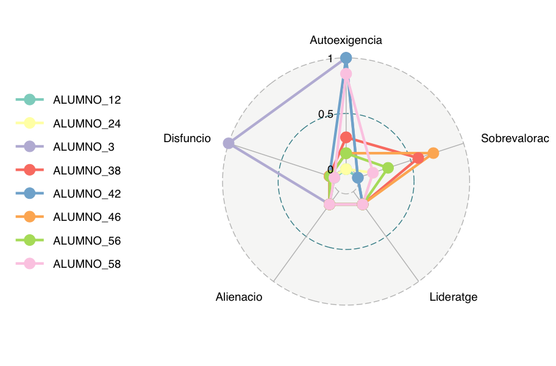

## 4.3 G03Terrorisme

|  | alumne | Autoexigencia | Sobrevaloracio | Lideratge | Alienacio | Disfuncio |
| --- | --- | --- | --- | --- | --- | --- |
| 7 | ALUMNO_7 | 0.4 | 0.6 | 0.200 | 0.200 | 0.146 |
| 8 | ALUMNO_8 | 0.6 | 0.4 | 0.200 | 0.200 | 0.603 |
| 10 | ALUMNO_10 | NA | NA | NA | NA | NA |
| 25 | ALUMNO_25 | NA | NA | NA | NA | NA |
| 34 | ALUMNO_34 | 0.4 | 0.6 | 0.200 | 0.200 | 0.151 |
| 36 | ALUMNO_36 | 0.6 | 0.4 | 0.143 | 0.143 | 1.000 |
| 40 | ALUMNO_40 | 0.8 | 0.2 | 0.200 | 0.200 | 0.654 |
| 43 | ALUMNO_43 | 0.0 | 1.0 | 0.143 | 0.143 | 0.000 |

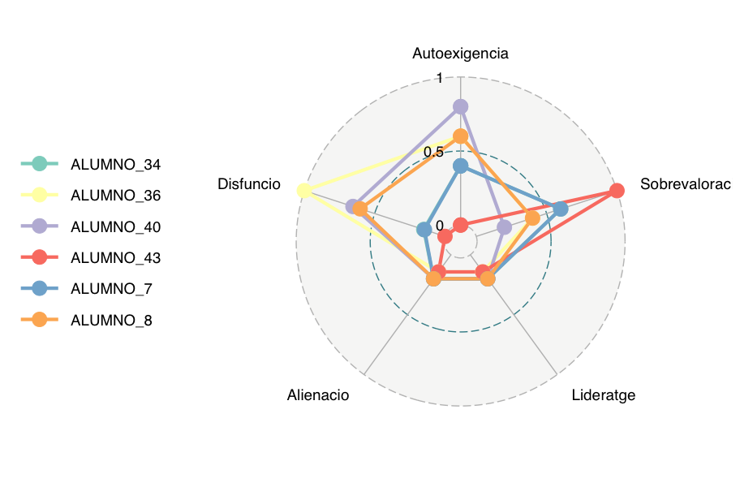

## 4.4 G04Billonarios

|  | alumne | Autoexigencia | Sobrevaloracio | Lideratge | Alienacio | Disfuncio |
| --- | --- | --- | --- | --- | --- | --- |
| 9 | ALUMNO_9 | 0.571 | 0.429 | 0.143 | 0.143 | 0.000 |
| 22 | ALUMNO_22 | 0.429 | 0.429 | 0.143 | 0.143 | 0.369 |
| 29 | ALUMNO_29 | 0.857 | 0.143 | 0.143 | 0.143 | 0.279 |
| 45 | ALUMNO_45 | 0.429 | 0.571 | 0.143 | 0.143 | 0.369 |
| 52 | ALUMNO_52 | 1.000 | 0.000 | 0.143 | 0.143 | 0.080 |
| 54 | ALUMNO_54 | 0.571 | 0.429 | 0.143 | 0.143 | 1.000 |
| 55 | ALUMNO_55 | 0.429 | 0.429 | 0.143 | 0.143 | 0.130 |
| 59 | ALUMNO_59 | 0.857 | 0.143 | 0.143 | 0.143 | 0.969 |

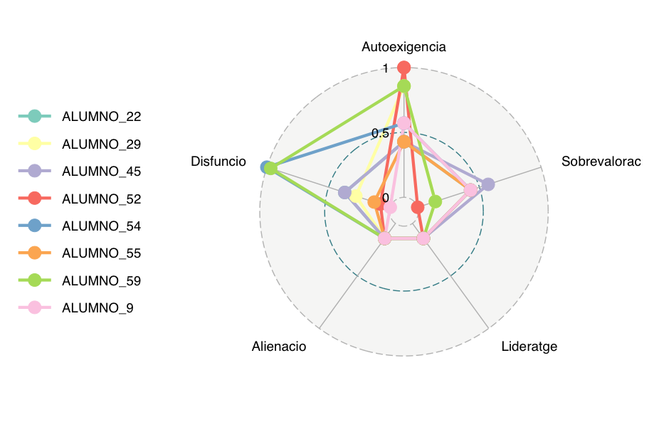

## 4.5 G05Marketing

|  | alumne | Autoexigencia | Sobrevaloracio | Lideratge | Alienacio | Disfuncio |
| --- | --- | --- | --- | --- | --- | --- |
| 4 | ALUMNO_4 | 1.000 | 0.000 | 0.143 | 0.143 | 1.000 |
| 13 | ALUMNO_13 | 0.714 | 0.286 | 0.143 | 0.143 | 0.020 |
| 30 | ALUMNO_30 | 0.714 | 0.286 | 0.143 | 0.143 | 0.000 |
| 39 | ALUMNO_39 | 0.143 | 0.857 | 0.143 | 0.143 | 0.010 |
| 41 | ALUMNO_41 | 1.000 | 0.000 | 0.143 | 0.143 | 0.649 |
| 51 | ALUMNO_51 | 0.000 | 0.857 | 0.143 | 0.143 | 0.000 |
| 53 | ALUMNO_53 | 0.143 | 0.714 | 0.143 | 0.143 | 0.010 |
| 62 | ALUMNO_62 | 0.571 | 0.286 | 0.143 | 0.143 | 0.000 |

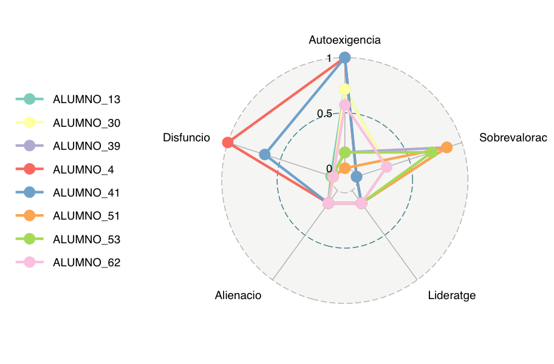

## 4.6 G06SalutMental

|  | alumne | Autoexigencia | Sobrevaloracio | Lideratge | Alienacio | Disfuncio |
| --- | --- | --- | --- | --- | --- | --- |
| 5 | ALUMNO_5 | 0.667 | 0.167 | 0.167 | 0.167 | 0.000 |
| 11 | ALUMNO_11 | 1.000 | 0.000 | 0.167 | 0.167 | 0.000 |
| 44 | ALUMNO_44 | 0.833 | 0.167 | 0.167 | 0.167 | 0.000 |
| 50 | ALUMNO_50 | 1.000 | 0.000 | 0.167 | 0.167 | 0.000 |
| 60 | ALUMNO_60 | 0.333 | 0.500 | 0.167 | 0.167 | 0.131 |
| 61 | ALUMNO_61 | 0.000 | 0.833 | 0.167 | 0.167 | 0.085 |
| 63 | ALUMNO_63 | 1.000 | 0.000 | 0.167 | 0.167 | 1.000 |

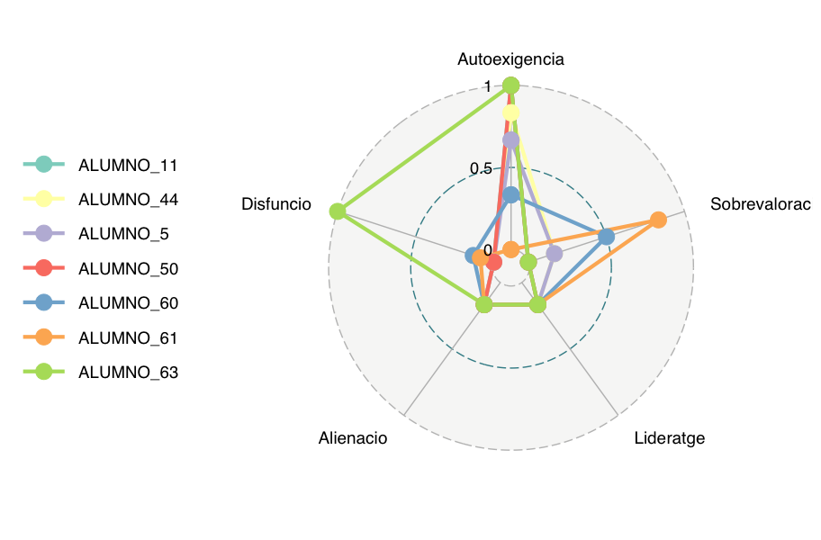

## 4.7 G07Salaries

|  | alumne | Autoexigencia | Sobrevaloracio | Lideratge | Alienacio | Disfuncio |
| --- | --- | --- | --- | --- | --- | --- |
| 2 | ALUMNO_2 | 1.000 | 0.000 | 0.167 | 0.167 | 1.000 |
| 15 | ALUMNO_15 | 0.000 | 0.667 | 0.167 | 0.167 | 0.112 |
| 17 | ALUMNO_17 | 0.333 | 0.167 | 0.167 | 0.167 | 0.209 |
| 28 | ALUMNO_28 | 0.833 | 0.167 | 0.167 | 0.167 | 0.000 |
| 33 | ALUMNO_33 | 0.833 | 0.167 | 0.167 | 0.167 | 0.002 |
| 35 | ALUMNO_35 | 0.000 | 0.833 | 0.167 | 0.167 | 0.002 |
| 57 | ALUMNO_57 | 0.667 | 0.167 | 0.167 | 0.167 | 0.002 |

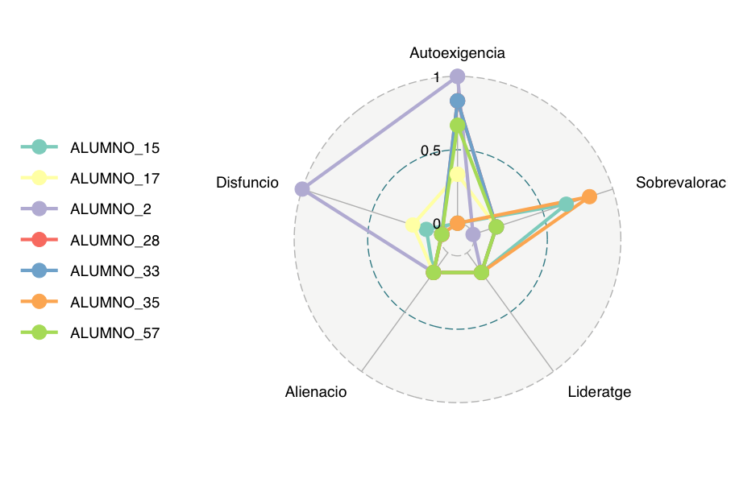

## 4.8 G08Pisa

|  | alumne | Autoexigencia | Sobrevaloracio | Lideratge | Alienacio | Disfuncio |
| --- | --- | --- | --- | --- | --- | --- |
| 6 | ALUMNO_6 | 0.4 | 0.4 | 0.125 | 0.125 | 0.690 |
| 14 | ALUMNO_14 | 0.6 | 0.4 | 0.200 | 0.200 | 0.000 |
| 18 | ALUMNO_18 | 0.6 | 0.4 | 0.200 | 0.200 | 0.010 |
| 20 | ALUMNO_20 | 0.6 | 0.4 | 0.125 | 0.125 | 1.000 |
| 21 | ALUMNO_21 | 0.6 | 0.4 | 0.200 | 0.200 | 0.010 |
| 23 | ALUMNO_23 | NA | NA | NA | NA | NA |
| 32 | ALUMNO_32 | 1.0 | 0.0 | 0.200 | 0.200 | 0.239 |
| 47 | ALUMNO_47 | NA | NA | NA | NA | NA |
| 49 | ALUMNO_49 | NA | NA | NA | NA | NA |

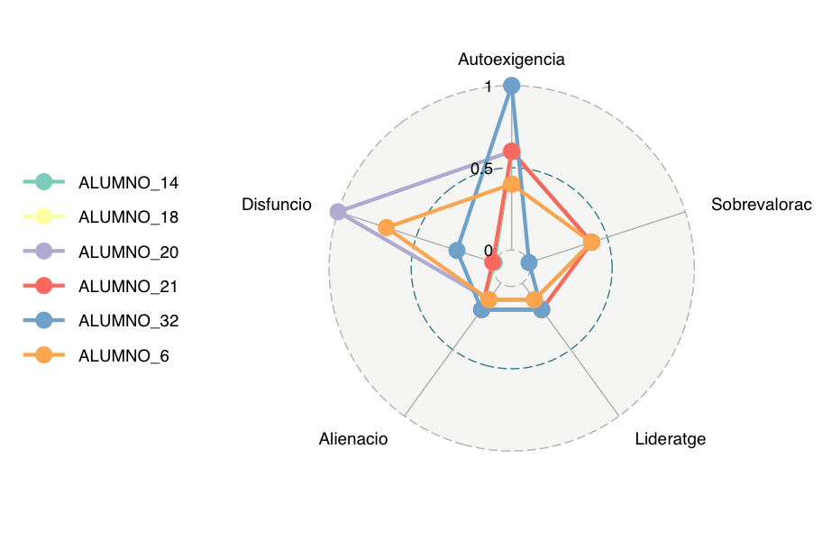

# 5 Análisi de grafos de alumnados

## 5.1 G01Aerolinies

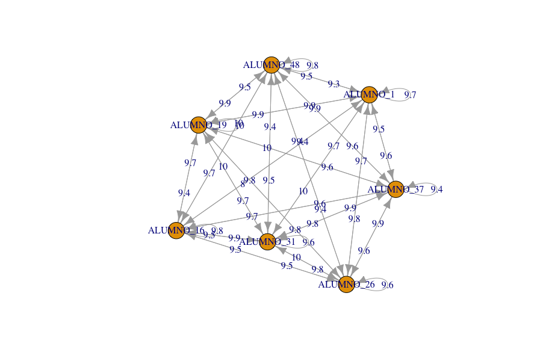

### 5.1.1 Centralidad de entrada (in-degree) y salida (out-degree) ponderada

|  | recibe | otorga |
| --- | --- | --- |
| ALUMNO_1 | 9.5 | 9.600000 |
| ALUMNO_16 | 9.7 | 9.371429 |
| ALUMNO_19 | 9.7 | 9.900000 |
| ALUMNO_26 | 9.7 | 9.642857 |
| ALUMNO_31 | 9.7 | 9.785714 |
| ALUMNO_37 | 9.7 | 9.657143 |
| ALUMNO_48 | 9.6 | 9.642857 |

### 5.1.2 Centralidad de intermediación (betweenness centrality)

| ALUMNO_1 | ALUMNO_16 | ALUMNO_19 | ALUMNO_26 | ALUMNO_31 | ALUMNO_37 | ALUMNO_48 |
| --- | --- | --- | --- | --- | --- | --- |
| 0 | 0 | 0 | 0 | 0 | 0 | 0 |

### 5.1.3 Cercanía (closeness centrality)

| ALUMNO_1 | ALUMNO_16 | ALUMNO_19 | ALUMNO_26 | ALUMNO_31 | ALUMNO_37 | ALUMNO_48 |
| --- | --- | --- | --- | --- | --- | --- |
| 1.615865 | 1.615922 | 1.647029 | 1.621434 | 1.646678 | 1.638566 | 1.615693 |

### 5.1.4 Identificar los estudiantes más influyentes y menos influyentes

| mas_influyentes | menos_influyentes |
| --- | --- |
| ALUMNO_16 | ALUMNO_1 |
| ALUMNO_19 | ALUMNO_48 |
| ALUMNO_26 | ALUMNO_37 |

### 5.1.5 Similaridad de Jaccard en conexiones de puntuación

|  | ALUMNO_1 | ALUMNO_16 | ALUMNO_19 | ALUMNO_26 | ALUMNO_31 | ALUMNO_37 | ALUMNO_48 |
| --- | --- | --- | --- | --- | --- | --- | --- |
| ALUMNO_1 | 1.000 | 0.714 | 0.714 | 0.714 | 0.714 | 0.714 | 0.714 |
| ALUMNO_16 | 0.714 | 1.000 | 0.714 | 0.714 | 0.714 | 0.714 | 0.714 |
| ALUMNO_19 | 0.714 | 0.714 | 1.000 | 0.714 | 0.714 | 0.714 | 0.714 |
| ALUMNO_26 | 0.714 | 0.714 | 0.714 | 1.000 | 0.714 | 0.714 | 0.714 |
| ALUMNO_31 | 0.714 | 0.714 | 0.714 | 0.714 | 1.000 | 0.714 | 0.714 |
| ALUMNO_37 | 0.714 | 0.714 | 0.714 | 0.714 | 0.714 | 1.000 | 0.714 |
| ALUMNO_48 | 0.714 | 0.714 | 0.714 | 0.714 | 0.714 | 0.714 | 1.000 |

## 5.2 G02Hotels

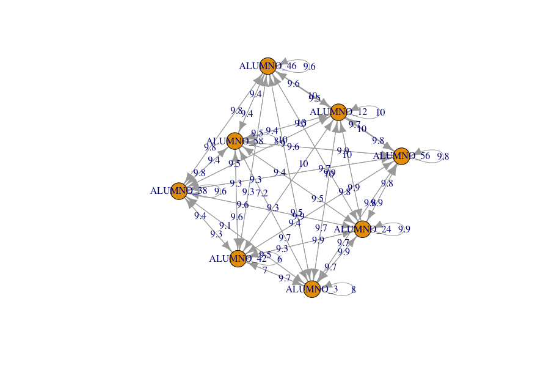

### 5.2.1 Centralidad de entrada (in-degree) y salida (out-degree) ponderada

|  | recibe | otorga |
| --- | --- | --- |
| ALUMNO_3 | 8.7500 | 9.4375 |
| ALUMNO_12 | 9.6500 | 10.0000 |
| ALUMNO_24 | 9.6500 | 9.8500 |
| ALUMNO_38 | 9.6500 | 9.5125 |
| ALUMNO_42 | 9.2000 | 8.6500 |
| ALUMNO_46 | 9.6500 | 9.4875 |
| ALUMNO_56 | 9.6500 | 9.7875 |
| ALUMNO_58 | 9.4875 | 8.9625 |

### 5.2.2 Centralidad de intermediación (betweenness centrality)

| ALUMNO_3 | ALUMNO_12 | ALUMNO_24 | ALUMNO_38 | ALUMNO_42 | ALUMNO_46 | ALUMNO_56 | ALUMNO_58 |
| --- | --- | --- | --- | --- | --- | --- | --- |
| 0 | 0 | 0 | 0 | 0 | 0 | 0 | 0 |

### 5.2.3 Cercanía (closeness centrality)

| ALUMNO_3 | ALUMNO_12 | ALUMNO_24 | ALUMNO_38 | ALUMNO_42 | ALUMNO_46 | ALUMNO_56 | ALUMNO_58 |
| --- | --- | --- | --- | --- | --- | --- | --- |
| 1.389347 | 1.428571 | 1.407829 | 1.389216 | 1.385125 | 1.383025 | 1.403928 | 1.385125 |

### 5.2.4 Identificar los estudiantes más influyentes y menos influyentes

| mas_influyentes | menos_influyentes |
| --- | --- |
| ALUMNO_12 | ALUMNO_3 |
| ALUMNO_24 | ALUMNO_42 |
| ALUMNO_38 | ALUMNO_58 |

### 5.2.5 Similaridad de Jaccard en conexiones de puntuación

|  | ALUMNO_3 | ALUMNO_12 | ALUMNO_24 | ALUMNO_38 | ALUMNO_42 | ALUMNO_46 | ALUMNO_56 | ALUMNO_58 |
| --- | --- | --- | --- | --- | --- | --- | --- | --- |
| ALUMNO_3 | 1.00 | 0.75 | 0.75 | 0.75 | 0.75 | 0.75 | 0.75 | 0.75 |
| ALUMNO_12 | 0.75 | 1.00 | 0.75 | 0.75 | 0.75 | 0.75 | 0.75 | 0.75 |
| ALUMNO_24 | 0.75 | 0.75 | 1.00 | 0.75 | 0.75 | 0.75 | 0.75 | 0.75 |
| ALUMNO_38 | 0.75 | 0.75 | 0.75 | 1.00 | 0.75 | 0.75 | 0.75 | 0.75 |
| ALUMNO_42 | 0.75 | 0.75 | 0.75 | 0.75 | 1.00 | 0.75 | 0.75 | 0.75 |
| ALUMNO_46 | 0.75 | 0.75 | 0.75 | 0.75 | 0.75 | 1.00 | 0.75 | 0.75 |
| ALUMNO_56 | 0.75 | 0.75 | 0.75 | 0.75 | 0.75 | 0.75 | 1.00 | 0.75 |
| ALUMNO_58 | 0.75 | 0.75 | 0.75 | 0.75 | 0.75 | 0.75 | 0.75 | 1.00 |

## 5.3 G03Terrorisme

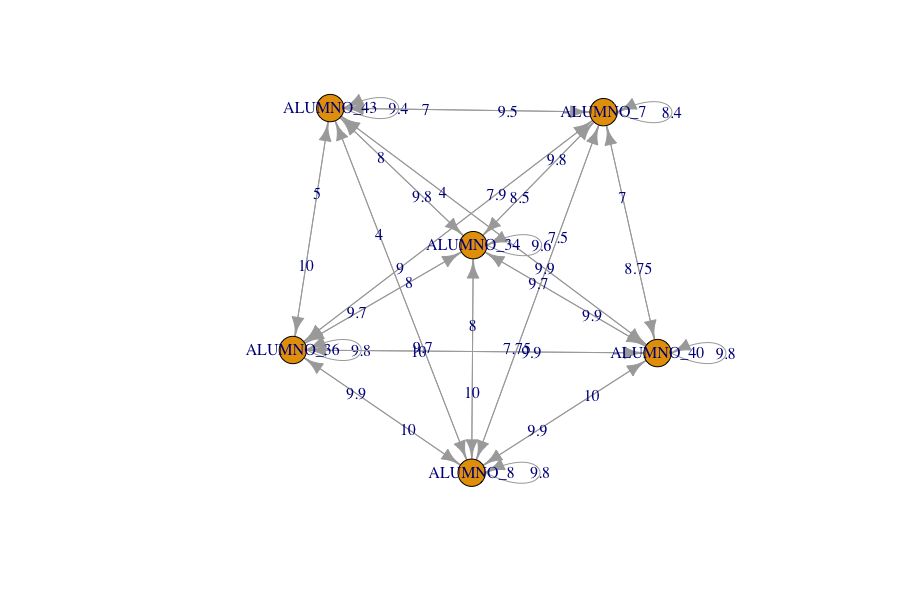

### 5.3.1 Centralidad de entrada (in-degree) y salida (out-degree) ponderada

|  | recibe | otorga |
| --- | --- | --- |
| ALUMNO_7 | 8.233333 | 8.350000 |
| ALUMNO_8 | 8.200000 | 9.525000 |
| ALUMNO_34 | 9.500000 | 8.933333 |
| ALUMNO_36 | 8.433333 | 9.733333 |
| ALUMNO_40 | 8.400000 | 9.708333 |
| ALUMNO_43 | 9.716667 | 6.233333 |

### 5.3.2 Centralidad de intermediación (betweenness centrality)

| ALUMNO_7 | ALUMNO_8 | ALUMNO_34 | ALUMNO_36 | ALUMNO_40 | ALUMNO_43 |
| --- | --- | --- | --- | --- | --- |
| 0 | 0 | 1.5 | 0 | 0 | 0 |

### 5.3.3 Cercanía (closeness centrality)

| ALUMNO_7 | ALUMNO_8 | ALUMNO_34 | ALUMNO_36 | ALUMNO_40 | ALUMNO_43 |
| --- | --- | --- | --- | --- | --- |
| 1.780205 | 1.879258 | 1.967789 | 1.944754 | 1.936836 | 1.95539 |

### 5.3.4 Identificar los estudiantes más influyentes y menos influyentes

| mas_influyentes | menos_influyentes |
| --- | --- |
| ALUMNO_43 | ALUMNO_8 |
| ALUMNO_34 | ALUMNO_7 |
| ALUMNO_36 | ALUMNO_40 |

### 5.3.5 Similaridad de Jaccard en conexiones de puntuación

|  | ALUMNO_7 | ALUMNO_8 | ALUMNO_34 | ALUMNO_36 | ALUMNO_40 | ALUMNO_43 |
| --- | --- | --- | --- | --- | --- | --- |
| ALUMNO_7 | 1.000 | 0.667 | 0.667 | 0.667 | 0.667 | 0.667 |
| ALUMNO_8 | 0.667 | 1.000 | 0.667 | 0.667 | 0.667 | 0.667 |
| ALUMNO_34 | 0.667 | 0.667 | 1.000 | 0.667 | 0.667 | 0.667 |
| ALUMNO_36 | 0.667 | 0.667 | 0.667 | 1.000 | 0.667 | 0.667 |
| ALUMNO_40 | 0.667 | 0.667 | 0.667 | 0.667 | 1.000 | 0.667 |
| ALUMNO_43 | 0.667 | 0.667 | 0.667 | 0.667 | 0.667 | 1.000 |

## 5.4 G04Billonarios

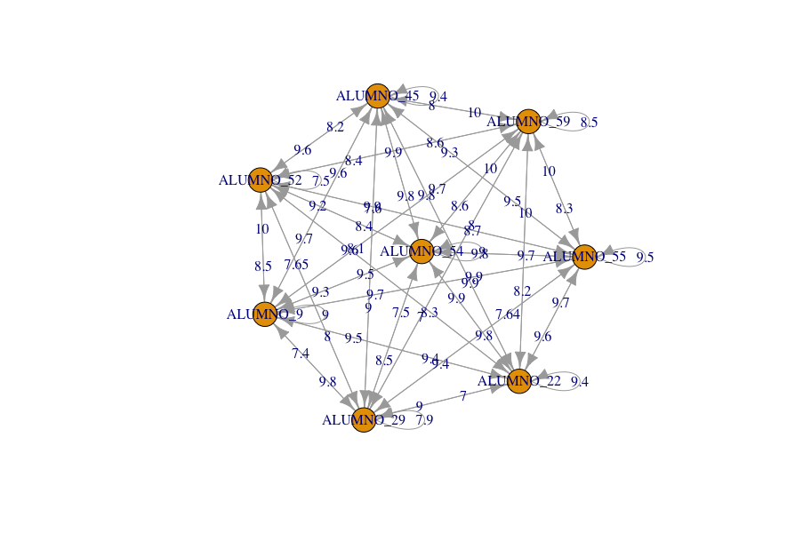

### 5.4.1 Centralidad de entrada (in-degree) y salida (out-degree) ponderada

|  | recibe | otorga |
| --- | --- | --- |
| ALUMNO_9 | 9.61250 | 8.90000 |
| ALUMNO_22 | 9.61250 | 8.95000 |
| ALUMNO_29 | 7.58625 | 8.57500 |
| ALUMNO_45 | 9.61250 | 8.97500 |
| ALUMNO_52 | 8.27500 | 8.98125 |
| ALUMNO_54 | 9.42500 | 9.06250 |
| ALUMNO_55 | 9.65000 | 9.11750 |
| ALUMNO_59 | 8.13750 | 9.35000 |

### 5.4.2 Centralidad de intermediación (betweenness centrality)

| ALUMNO_9 | ALUMNO_22 | ALUMNO_29 | ALUMNO_45 | ALUMNO_52 | ALUMNO_54 | ALUMNO_55 | ALUMNO_59 |
| --- | --- | --- | --- | --- | --- | --- | --- |
| 0 | 0 | 0 | 0 | 0 | 0 | 0 | 0 |

### 5.4.3 Cercanía (closeness centrality)

| ALUMNO_9 | ALUMNO_22 | ALUMNO_29 | ALUMNO_45 | ALUMNO_52 | ALUMNO_54 | ALUMNO_55 | ALUMNO_59 |
| --- | --- | --- | --- | --- | --- | --- | --- |
| 1.389347 | 1.378067 | 1.252673 | 1.378067 | 1.316971 | 1.359311 | 1.391208 | 1.343415 |

### 5.4.4 Identificar los estudiantes más influyentes y menos influyentes

| mas_influyentes | menos_influyentes |
| --- | --- |
| ALUMNO_55 | ALUMNO_29 |
| ALUMNO_9 | ALUMNO_59 |
| ALUMNO_22 | ALUMNO_52 |

### 5.4.5 Similaridad de Jaccard en conexiones de puntuación

|  | ALUMNO_9 | ALUMNO_22 | ALUMNO_29 | ALUMNO_45 | ALUMNO_52 | ALUMNO_54 | ALUMNO_55 | ALUMNO_59 |
| --- | --- | --- | --- | --- | --- | --- | --- | --- |
| ALUMNO_9 | 1.00 | 0.75 | 0.75 | 0.75 | 0.75 | 0.75 | 0.75 | 0.75 |
| ALUMNO_22 | 0.75 | 1.00 | 0.75 | 0.75 | 0.75 | 0.75 | 0.75 | 0.75 |
| ALUMNO_29 | 0.75 | 0.75 | 1.00 | 0.75 | 0.75 | 0.75 | 0.75 | 0.75 |
| ALUMNO_45 | 0.75 | 0.75 | 0.75 | 1.00 | 0.75 | 0.75 | 0.75 | 0.75 |
| ALUMNO_52 | 0.75 | 0.75 | 0.75 | 0.75 | 1.00 | 0.75 | 0.75 | 0.75 |
| ALUMNO_54 | 0.75 | 0.75 | 0.75 | 0.75 | 0.75 | 1.00 | 0.75 | 0.75 |
| ALUMNO_55 | 0.75 | 0.75 | 0.75 | 0.75 | 0.75 | 0.75 | 1.00 | 0.75 |
| ALUMNO_59 | 0.75 | 0.75 | 0.75 | 0.75 | 0.75 | 0.75 | 0.75 | 1.00 |

## 5.5 G05Marketing

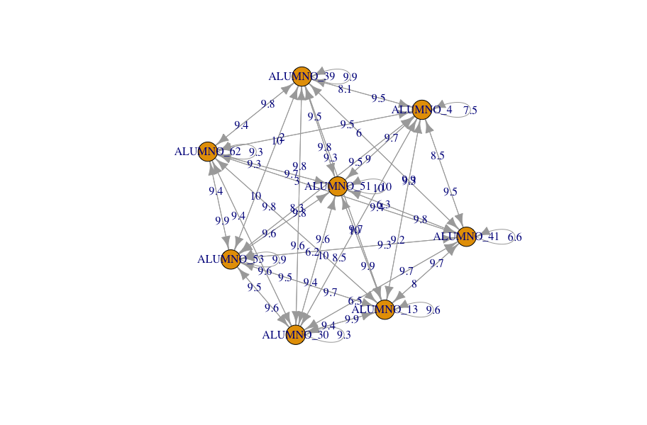

### 5.5.1 Centralidad de entrada (in-degree) y salida (out-degree) ponderada

|  | recibe | otorga |
| --- | --- | --- |
| ALUMNO_4 | 7.7625 | 9.2625 |
| ALUMNO_13 | 9.6500 | 9.5000 |
| ALUMNO_30 | 9.6500 | 8.9875 |
| ALUMNO_39 | 9.6500 | 9.0500 |
| ALUMNO_41 | 6.3875 | 9.1625 |
| ALUMNO_51 | 9.6500 | 9.2750 |
| ALUMNO_53 | 9.6500 | 9.1125 |
| ALUMNO_62 | 9.6500 | 7.7000 |

### 5.5.2 Centralidad de intermediación (betweenness centrality)

| ALUMNO_4 | ALUMNO_13 | ALUMNO_30 | ALUMNO_39 | ALUMNO_41 | ALUMNO_51 | ALUMNO_53 | ALUMNO_62 |
| --- | --- | --- | --- | --- | --- | --- | --- |
| 0 | 2 | 0 | 0 | 0 | 0 | 0 | 0 |

### 5.5.3 Cercanía (closeness centrality)

| ALUMNO_4 | ALUMNO_13 | ALUMNO_30 | ALUMNO_39 | ALUMNO_41 | ALUMNO_51 | ALUMNO_53 | ALUMNO_62 |
| --- | --- | --- | --- | --- | --- | --- | --- |
| 1.379015 | 1.405879 | 1.39151 | 1.385031 | 1.360681 | 1.395723 | 1.382934 | 1.385125 |

### 5.5.4 Identificar los estudiantes más influyentes y menos influyentes

| mas_influyentes | menos_influyentes |
| --- | --- |
| ALUMNO_30 | ALUMNO_41 |
| ALUMNO_13 | ALUMNO_4 |
| ALUMNO_39 | ALUMNO_51 |

### 5.5.5 Similaridad de Jaccard en conexiones de puntuación

|  | ALUMNO_4 | ALUMNO_13 | ALUMNO_30 | ALUMNO_39 | ALUMNO_41 | ALUMNO_51 | ALUMNO_53 | ALUMNO_62 |
| --- | --- | --- | --- | --- | --- | --- | --- | --- |
| ALUMNO_4 | 1.00 | 0.75 | 0.75 | 0.75 | 0.75 | 0.75 | 0.75 | 0.75 |
| ALUMNO_13 | 0.75 | 1.00 | 0.75 | 0.75 | 0.75 | 0.75 | 0.75 | 0.75 |
| ALUMNO_30 | 0.75 | 0.75 | 1.00 | 0.75 | 0.75 | 0.75 | 0.75 | 0.75 |
| ALUMNO_39 | 0.75 | 0.75 | 0.75 | 1.00 | 0.75 | 0.75 | 0.75 | 0.75 |
| ALUMNO_41 | 0.75 | 0.75 | 0.75 | 0.75 | 1.00 | 0.75 | 0.75 | 0.75 |
| ALUMNO_51 | 0.75 | 0.75 | 0.75 | 0.75 | 0.75 | 1.00 | 0.75 | 0.75 |
| ALUMNO_53 | 0.75 | 0.75 | 0.75 | 0.75 | 0.75 | 0.75 | 1.00 | 0.75 |
| ALUMNO_62 | 0.75 | 0.75 | 0.75 | 0.75 | 0.75 | 0.75 | 0.75 | 1.00 |

## 5.6 G06SalutMental

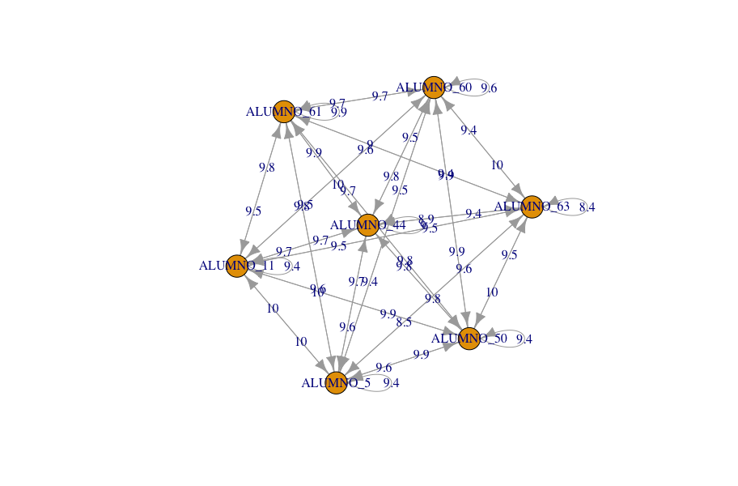

### 5.6.1 Centralidad de entrada (in-degree) y salida (out-degree) ponderada

|  | recibe | otorga |
| --- | --- | --- |
| ALUMNO_5 | 9.700000 | 9.442857 |
| ALUMNO_11 | 9.700000 | 9.657143 |
| ALUMNO_44 | 9.557143 | 9.557143 |
| ALUMNO_50 | 9.700000 | 9.814286 |
| ALUMNO_60 | 9.700000 | 9.600000 |
| ALUMNO_61 | 9.700000 | 9.685714 |
| ALUMNO_63 | 9.100000 | 9.400000 |

### 5.6.2 Centralidad de intermediación (betweenness centrality)

| ALUMNO_5 | ALUMNO_11 | ALUMNO_44 | ALUMNO_50 | ALUMNO_60 | ALUMNO_61 | ALUMNO_63 |
| --- | --- | --- | --- | --- | --- | --- |
| 0 | 0 | 0 | 0 | 0 | 0 | 0 |

### 5.6.3 Cercanía (closeness centrality)

| ALUMNO_5 | ALUMNO_11 | ALUMNO_44 | ALUMNO_50 | ALUMNO_60 | ALUMNO_61 | ALUMNO_63 |
| --- | --- | --- | --- | --- | --- | --- |
| 1.624501 | 1.627171 | 1.621665 | 1.649888 | 1.624501 | 1.624436 | 1.607211 |

### 5.6.4 Identificar los estudiantes más influyentes y menos influyentes

| mas_influyentes | menos_influyentes |
| --- | --- |
| ALUMNO_11 | ALUMNO_63 |
| ALUMNO_50 | ALUMNO_44 |
| ALUMNO_60 | ALUMNO_5 |

### 5.6.5 Similaridad de Jaccard en conexiones de puntuación

|  | ALUMNO_5 | ALUMNO_11 | ALUMNO_44 | ALUMNO_50 | ALUMNO_60 | ALUMNO_61 | ALUMNO_63 |
| --- | --- | --- | --- | --- | --- | --- | --- |
| ALUMNO_5 | 1.000 | 0.714 | 0.714 | 0.714 | 0.714 | 0.714 | 0.714 |
| ALUMNO_11 | 0.714 | 1.000 | 0.714 | 0.714 | 0.714 | 0.714 | 0.714 |
| ALUMNO_44 | 0.714 | 0.714 | 1.000 | 0.714 | 0.714 | 0.714 | 0.714 |
| ALUMNO_50 | 0.714 | 0.714 | 0.714 | 1.000 | 0.714 | 0.714 | 0.714 |
| ALUMNO_60 | 0.714 | 0.714 | 0.714 | 0.714 | 1.000 | 0.714 | 0.714 |
| ALUMNO_61 | 0.714 | 0.714 | 0.714 | 0.714 | 0.714 | 1.000 | 0.714 |
| ALUMNO_63 | 0.714 | 0.714 | 0.714 | 0.714 | 0.714 | 0.714 | 1.000 |

## 5.7 G07Salaries

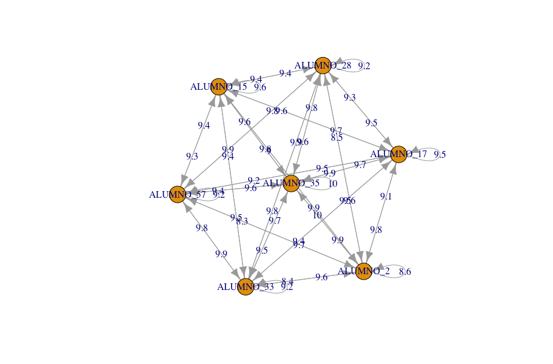

### 5.7.1 Centralidad de entrada (in-degree) y salida (out-degree) ponderada

|  | recibe | otorga |
| --- | --- | --- |
| ALUMNO_2 | 8.842857 | 9.585714 |
| ALUMNO_15 | 9.600000 | 9.428571 |
| ALUMNO_17 | 9.528571 | 9.500000 |
| ALUMNO_28 | 9.571429 | 9.414286 |
| ALUMNO_33 | 9.585714 | 9.385714 |
| ALUMNO_35 | 9.700000 | 9.800000 |
| ALUMNO_57 | 9.585714 | 9.300000 |

### 5.7.2 Centralidad de intermediación (betweenness centrality)

| ALUMNO_2 | ALUMNO_15 | ALUMNO_17 | ALUMNO_28 | ALUMNO_33 | ALUMNO_35 | ALUMNO_57 |
| --- | --- | --- | --- | --- | --- | --- |
| 0 | 0 | 0 | 0 | 0 | 0 | 0 |

### 5.7.3 Cercanía (closeness centrality)

| ALUMNO_2 | ALUMNO_15 | ALUMNO_17 | ALUMNO_28 | ALUMNO_33 | ALUMNO_35 | ALUMNO_57 |
| --- | --- | --- | --- | --- | --- | --- |
| 1.6274 | 1.60212 | 1.60789 | 1.613231 | 1.613408 | 1.63305 | 1.610498 |

### 5.7.4 Identificar los estudiantes más influyentes y menos influyentes

| mas_influyentes | menos_influyentes |
| --- | --- |
| ALUMNO_35 | ALUMNO_2 |
| ALUMNO_15 | ALUMNO_17 |
| ALUMNO_57 | ALUMNO_28 |

### 5.7.5 Similaridad de Jaccard en conexiones de puntuación

|  | ALUMNO_2 | ALUMNO_15 | ALUMNO_17 | ALUMNO_28 | ALUMNO_33 | ALUMNO_35 | ALUMNO_57 |
| --- | --- | --- | --- | --- | --- | --- | --- |
| ALUMNO_2 | 1.000 | 0.714 | 0.714 | 0.714 | 0.714 | 0.714 | 0.714 |
| ALUMNO_15 | 0.714 | 1.000 | 0.714 | 0.714 | 0.714 | 0.714 | 0.714 |
| ALUMNO_17 | 0.714 | 0.714 | 1.000 | 0.714 | 0.714 | 0.714 | 0.714 |
| ALUMNO_28 | 0.714 | 0.714 | 0.714 | 1.000 | 0.714 | 0.714 | 0.714 |
| ALUMNO_33 | 0.714 | 0.714 | 0.714 | 0.714 | 1.000 | 0.714 | 0.714 |
| ALUMNO_35 | 0.714 | 0.714 | 0.714 | 0.714 | 0.714 | 1.000 | 0.714 |
| ALUMNO_57 | 0.714 | 0.714 | 0.714 | 0.714 | 0.714 | 0.714 | 1.000 |

## 5.8 G08Pisa

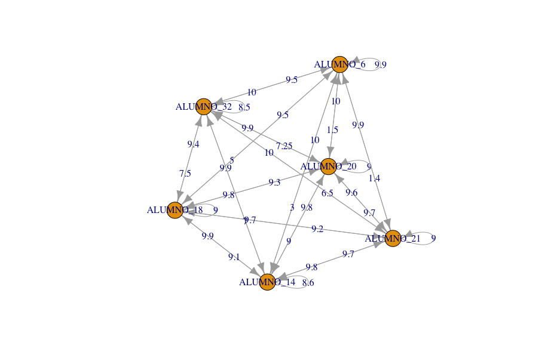

### 5.8.1 Centralidad de entrada (in-degree) y salida (out-degree) ponderada

|  | recibe | otorga |
| --- | --- | --- |
| ALUMNO_6 | 5.133333 | 9.800000 |
| ALUMNO_14 | 9.650000 | 7.750000 |
| ALUMNO_18 | 9.250000 | 8.483333 |
| ALUMNO_20 | 9.566667 | 7.741667 |
| ALUMNO_21 | 9.666667 | 7.583333 |
| ALUMNO_32 | 7.708333 | 9.616667 |

### 5.8.2 Centralidad de intermediación (betweenness centrality)

| ALUMNO_6 | ALUMNO_14 | ALUMNO_18 | ALUMNO_20 | ALUMNO_21 | ALUMNO_32 |
| --- | --- | --- | --- | --- | --- |
| 0 | 0 | 0 | 0 | 0 | 3 |

### 5.8.3 Cercanía (closeness centrality)

| ALUMNO_6 | ALUMNO_14 | ALUMNO_18 | ALUMNO_20 | ALUMNO_21 | ALUMNO_32 |
| --- | --- | --- | --- | --- | --- |
| 1.975218 | 1.975887 | 1.931285 | 1.967789 | 1.963724 | 1.966943 |

### 5.8.4 Identificar los estudiantes más influyentes y menos influyentes

| mas_influyentes | menos_influyentes |
| --- | --- |
| ALUMNO_21 | ALUMNO_6 |
| ALUMNO_14 | ALUMNO_32 |
| ALUMNO_20 | ALUMNO_18 |

### 5.8.5 Similaridad de Jaccard en conexiones de puntuación

|  | ALUMNO_6 | ALUMNO_14 | ALUMNO_18 | ALUMNO_20 | ALUMNO_21 | ALUMNO_32 |
| --- | --- | --- | --- | --- | --- | --- |
| ALUMNO_6 | 1.000 | 0.667 | 0.667 | 0.667 | 0.667 | 0.667 |
| ALUMNO_14 | 0.667 | 1.000 | 0.667 | 0.667 | 0.667 | 0.667 |
| ALUMNO_18 | 0.667 | 0.667 | 1.000 | 0.667 | 0.667 | 0.667 |
| ALUMNO_20 | 0.667 | 0.667 | 0.667 | 1.000 | 0.667 | 0.667 |
| ALUMNO_21 | 0.667 | 0.667 | 0.667 | 0.667 | 1.000 | 0.667 |
| ALUMNO_32 | 0.667 | 0.667 | 0.667 | 0.667 | 0.667 | 1.000 |

# 6 Clustering del alumnado

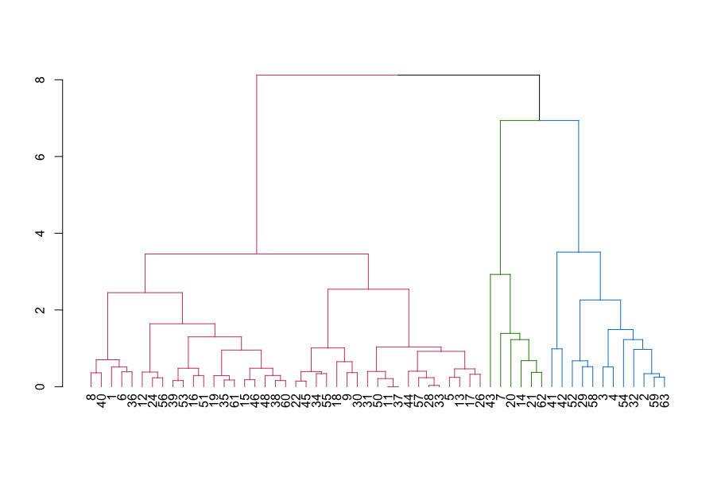

# 7 Perfilado del alumnado a partir del clustering

## 7.1 Variables quantitativas

|  | Eta2 | P-value |
| --- | --- | --- |
| mitCEestudiant | 0.6943701 | 0.0000000 |
| autoev | 0.6898317 | 0.0000000 |
| Autoexigencia | 0.3356803 | 0.0000160 |
| Sobrevaloracio | 0.2709655 | 0.0001969 |
| Disfuncio | 0.2501757 | 0.0004206 |

### 7.1.1 Descriptiva por cluster

#### 7.1.1.1 Cluster 1

|  | v.test | Mean in category | Overall mean | sd in category | Overall sd | p.value |
| --- | --- | --- | --- | --- | --- | --- |
| autoev | 5.666187 | 9.5923077 | 9.1631579 | 0.2885726 | 0.8342728 | 0.0000000 |
| mitCEestudiant | 3.384883 | 9.4372308 | 9.1966842 | 0.3660784 | 0.7827906 | 0.0007121 |
| Sobrevaloracio | 2.379725 | 0.4137973 | 0.3522974 | 0.2702829 | 0.2846674 | 0.0173256 |
| Disfuncio | -2.995139 | 0.1540000 | 0.2530526 | 0.2662214 | 0.3642832 | 0.0027432 |
| Autoexigencia | -3.416135 | 0.4327228 | 0.5401838 | 0.3232959 | 0.3465020 | 0.0006352 |

#### 7.1.1.2 Cluster 2

|  | v.test | Mean in category | Overall mean | sd in category | Overall sd | p.value |
| --- | --- | --- | --- | --- | --- | --- |
| Autoexigencia | 4.331497 | 0.9285714 | 0.5401838 | 0.1237179 | 0.3465020 | 0.0000148 |
| Disfuncio | 3.735275 | 0.6051667 | 0.2530526 | 0.4192175 | 0.3642832 | 0.0001875 |
| Sobrevaloracio | -3.812802 | 0.0714286 | 0.3522974 | 0.1237179 | 0.2846674 | 0.0001374 |
| autoev | -5.966771 | 7.8750000 | 9.1631579 | 0.8317902 | 0.8342728 | 0.0000000 |

#### 7.1.1.3 Cluster 3

|  | v.test | Mean in category | Overall mean | sd in category | Overall sd | p.value |
| --- | --- | --- | --- | --- | --- | --- |
| mitCEestudiant | -6.229576 | 7.296833 | 9.196684 | 0.8281788 | 0.7827906 | 0 |

### 7.1.2 Profiling visual por cluster

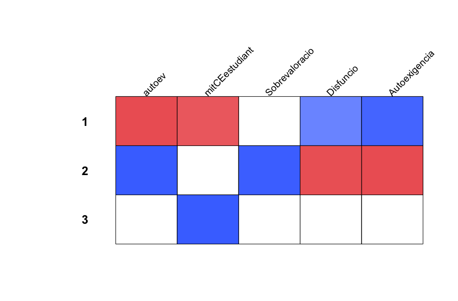

NULL